# Association rules

Movie recommender systems

Mohammad amin Roohi

2018-07-22 04:19:16

> با استفاده از داده نظرهای فیلم به سوالات زیر پاسخ دهید.

```r
library(readr)
library(dplyr)
library(stringi)
library(stringr)
library(ggplot2)
library(corrplot)
library(wordcloud)

read <- function(fileName, separators) {
  data <- readLines(con <- file(fileName))
  close(con)
  records <- strsplit(data , split = "::")
  dataFrame <- data.frame(t(sapply(records,c)))
  rownames(dataFrame) <- 1: nrow(dataFrame)
  return(as.data.frame(dataFrame,stringsAsFactors = FALSE))
}


substrRight <- function(x, n){
    substr(x, nchar(x)-n, nchar(x) - 1)
}


movies = read("D:/University/Semester8/Data analysis/week12/hw_12/ml-10M100K/movies.dat" , "::")
colnames(movies) = c("MovieID" , "Title" , "Genres")

ratings = read("D:/University/Semester8/Data analysis/week12/hw_12/ml-10M100K/ratings.dat" , "::")
colnames(ratings) = c("UserID" , "MovieID" , "Rating" , "Timestamp")

tags = read("D:/University/Semester8/Data analysis/week12/hw_12/ml-10M100K/tags.dat" , "::")
colnames(tags) = c("UserID" , "MovieID" , "Tag" , "Timestamp")
```

۱. آماره های زیر را بیابید. الف. محبوب ترین فیلم کدام است؟ ب. بیشترین نظرات درباره چه فیلمی داده شده است؟ پ. منفورترین فیلم کدام است؟ ت. تعداد فیلم های ساخته شده در هر سال ث. در هر سالی مردم به چه ژانری علاقه مند بوده اند.

به علت زیاد بودن محاسبات و طولانی شدن زمان اجرا تعداد کم تری از فیلم ها مورد را مورد بررسی قرار دادیم:

```r
score = NULL
votes_number = NULL


for(i in 1:10){
  x = ratings %>% filter(MovieID == i)
  score = c(score , mean(as.numeric(x$Rating)))
  votes_number = c(votes_number , dim(x)[1])


}

m = match(max(score) , score)
print("Most POPULAR film is:")
```

```
## [1] "Most POPULAR film is:"
```

```r
print(movies[m ,])
```

```
##   MovieID            Title                                      Genres
## 1       1 Toy Story (1995) Adventure|Animation|Children|Comedy|Fantasy
```

```r
m1 = match(max(votes_number) , votes_number)
print("Most Number for voting is for:")
```

```
## [1] "Most Number for voting is for:"
```

```r
print(movies[m1 ,])
```

```
##   MovieID            Title                                      Genres
## 1       1 Toy Story (1995) Adventure|Animation|Children|Comedy|Fantasy
```

```r
m3 = match(min(score) , score)
print("Most HATED film is:")
```

```
## [1] "Most HATED film is:"
```

```r
print(movies[m3 ,])
```

```
##   MovieID                    Title               Genres
## 4       4 Waiting to Exhale (1995) Comedy|Drama|Romance
```

```r
number_per_year = NULL
years = NULL

for(i in movies$Title){

  years = c(years , substrRight(as.character(i) , 4))


}
data = data.frame(table(years))
colnames(data) = c("years" , "freq")


print("Maximum number of film is for 2002 by 441")
```

```
## [1] "Maximum number of film is for 2002 by 441"
```

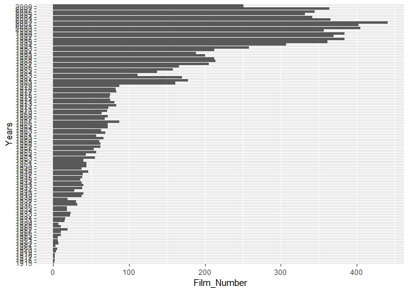

```r
ggplot(data , aes(years , freq)) + geom_col() + xlab("Years") + ylab("Film_Number") + coord_flip()
```

```r
Genres = c("Action","Adventure", "Animation","Children","Comedy","Crime","Documentary","Drama","Fantasy","Film-Noir","Horror","Musical","Mystery","Romance","Sci-Fi","Thriller","War","Western" , "IMAX")

data1 = movies %>% mutate(year = years)

popular_genres_in_year = NULL

y = sort(as.numeric(unique(years)))
y = as.character(y)
#
#for(i in y){
  #genres_num_per_year = rep(0 , 18)
  #x = data1 %>% filter(year == i)
  #for(j in x$Genres){
    #g = as.character(j)
    #for(k in 1:18){
      #if(str_detect(g , Genres[k])){
        #genres_num_per_year[k] = genres_num_per_year + 1
      #}
    #}
  #}

  #popular_genres_in_year = c(popular_genres_in_year , #Genres[match(max(genres_num_per_year),genres_num_per_year)])
#}


#genres_per_yer = data.frame(y , popular_genres_in_year)
#colnames(genres_per_yer) = c("Year","Popular Genres")
#print(genres_per_yer)
```

۲. ژانر فیلم ها را استخراج نمایید. سپس آماره های زیر را استخراج نمایید. الف. نمودار ستونی تعداد فیلم های هر ژانر ب. نمودار همبستگی ژانرها پ. متوسط امتیاز به هر ژانر ت. دوران طلایی فیلم سازی

```r
Movies_Genres = NULL
Movies_Genres_Number = rep(0 , length(Movies_Genres))

for(i in movies$Genres){
  x = i %>% str_split("[|]")
  Movies_Genres = c(Movies_Genres , x[[1]])


}

Movies_Genres1 = unique(Movies_Genres)

print("Movies Genres :  ")
```

```
## [1] "Movies Genres :  "
```

```r
print(Movies_Genres1)
```

```
##  [1] "Adventure"          "Animation"          "Children"
##  [4] "Comedy"             "Fantasy"            "Romance"
##  [7] "Drama"              "Action"             "Crime"
## [10] "Thriller"           "Horror"             "Mystery"
## [13] "Sci-Fi"             "IMAX"               "Documentary"
## [16] "War"                "Musical"            "Film-Noir"
## [19] "Western"            "(no genres listed)"
```

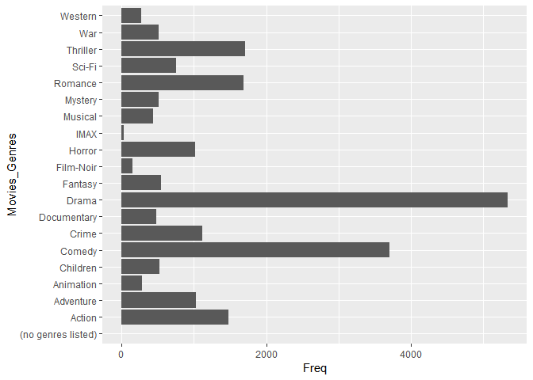

```r
table_genres = data.frame(table(Movies_Genres))
ggplot(table_genres , aes(x = Movies_Genres , y = Freq)) + geom_col() + coord_flip()
```

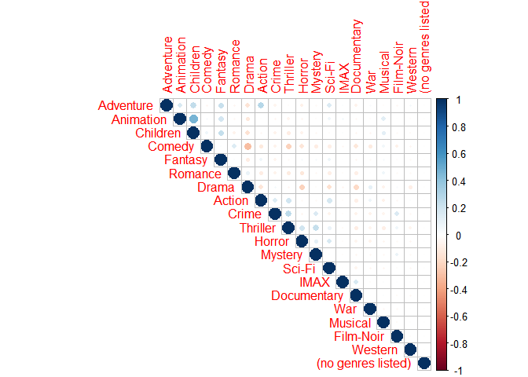

```r
table_for_cor = NULL

for(i in movies$Genres){
  y = rep(0 , 20)
  x = i %>% str_split("[|]")
  x = match(x[[1]] , Movies_Genres1)
  y[x] = 1
  table_for_cor = rbind(table_for_cor , y)


}
colnames(table_for_cor) = Movies_Genres1

M <- cor(table_for_cor)
corrplot(M, type = "upper")
```

```r
Genres_Score = NULL

for(i in Movies_Genres1){
  x = movies %>% filter(movies$Genres %>% str_detect(i))
  x = ratings %>% filter(ratings$MovieID %in% x$MovieID)
  x = mean(as.numeric(x$Rating))/2
  Genres_Score = c(Genres_Score , x)
}




gen_sco_tlb = rbind(Movies_Genres1 , Genres_Score)

print(gen_sco_tlb)
```

[output not shown]

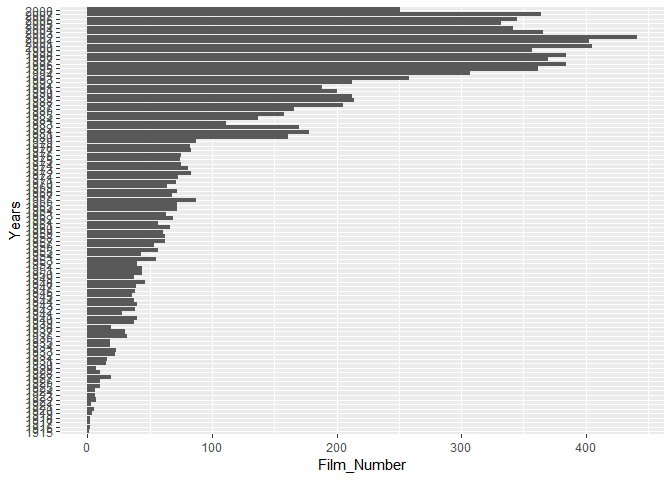

```r
ggplot(data , aes(years , freq)) + geom_col() + xlab("Years") + ylab("Film_Number") +coord_flip()
```

۳. نمودار ابر لغات را بر حسب کلمات عنوان فیلم ها رسم نمایید.

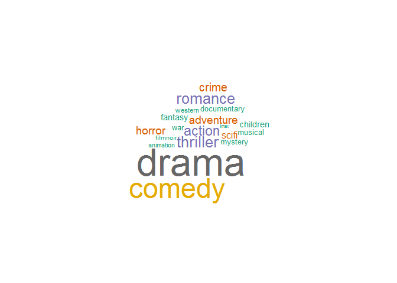

```r
wordcloud(Movies_Genres,colors=brewer.pal(8, "Dark2"))
```

***

۴. با استفاده از قوانین همبستگی یک توصیه گر برای فیلم ها بسازید. شبیه ترین فیلم ها به لیست زیر را پیدا کنید.

- Castle in the Sky (1986)
- Cast Away (2000)
- No Country for Old Men (2007)
- Memento (2000)

۵. تمرین سخت: در گیت هاب برای خود اکانت درست کنید. همه تمرین های خود را آنجا بارگذاری کنید! و لینک آن را ارسال نمایید.

https://gitlab.com/m5a0r7/data-analysis-weekly_homeworks/tree/master

۶. پنج انتقاد از درس و نحوه تدریس را بیان کنید.

حجم درس زیاد است!

اسلاید های درس مطالب درس که در کلاس مطرح می شوند را به خوبی پوشش نمی دهند.

موعد تحویل و فاز های مختلف پروژه مناسب نبودند. به طور واضح بیان نشده بود که در هر فاز از پروژه چه چیزی مورد انتظار است.

مطالب تئوری پراکنده بودند و منبعی خوب و با حجم متعادل تداشتیم.

تمرینات با داده هایی که نسبتا منظم و خوب! بودند انجام می گرفت ولی بسیاری داده ها هستند که نقص های فراوانی دارند. اگر کمی به این موضوع که با داده هایی که بد هستند! چطور رفتار کنیم پرداخته می شد خوب بود.

بهتر بود به مباحث crawling بیشتر پرداخته می شد.

۷. پنج پیشنهاد برای بهتر شدن درس بیان کنید.

تمرین ها واضح تر بیان شوند. خواسته تمرین ها در مواری گنگ مطرح می شد.

اگر دستیار آموزشی برای کار های نرم افزاری درس در نظر گرفته شود بهتر است.

اگر در gitlab یا سایت های مشابه اکانتی برای درس ساخته شود و کد های سر کلاس و کد های مفید در آن گذاشته شود مفید خواهد بود.

اگر بعضی از سوال های تمرین نیمه تکمیل باشند که دانشجویان آن ها را تکمیل کنند با این هدف که با روند منطقی و تمیر کد زدن آشنا شوند.

یک منبع خوب برای مباحث تئوری در نظر گرفته شود…با حجمی معقول

۸. سه موضوع آماری جدید برای جایگزینی در سرفصل ها پیشنهاد دهید.

تشخیص حرکات بدن با استفاده از داده هایی مثل CAD_60 و…

مباحث ژنومیک و بیوانفورماتیک

مباحث بلاکچین و بیت کوین

۹. سه داده جالب برای کار در کلاس پیشنهاد دهید.

CAD_60

Every song you have heard (almost)! from Kaggle

All the news from Kaggle

۱۰. چهار نکته مهمی که در کلاس یاد گرفتید را بیان کنید.

ساختن آزمون فرض و ادعا کردن بر اساس داده

کار های گرافیکی زیبایی که با R می توان انجام داد نظیر ابر لغات و…

کوچک کردن ابعاد داده با PCA

مباحث prediction و بحث های پیرامونش نظیر overfitting و …